# Step 2 — Analysis

Action and Relevance conditions vs Corrected Control (origcontrol1/2)

Nicole Cooper

2026-07-06

**N = 1211** (origcontrol1: 153 | origcontrol2: 152 | claudecontrol: 302 | relevance: 306 | action: 298 | origcontrol: 0)

Between-subjects, 5 conditions. Reference level: **origcontrol1**. Each outcome is modeled separately and z-scored prior to modeling. Primary contrasts: **relevance** and **action** vs origcontrol1. origcontrol2 and claudecontrol are retained in the data (and in the variant analysis) but excluded from the primary condition-effect tables and plots.

# 1. Primary analysis: condition effects

## Summary

| Outcome | Contrast | B | SE | t | p |  | Cohen's d | d CI low | d CI high |
| --- | --- | --- | --- | --- | --- | --- | --- | --- | --- |
| Contact reps to support funding | action | -0.045 | 0.1 | -0.46 | 0.649 |  | 0.045 | -0.15 | 0.24 |
| Contact reps to support funding | relevance | -0.031 | 0.099 | -0.31 | 0.755 |  | 0.03 | -0.164 | 0.224 |
| Disapproval of funding cuts | action | -0.02 | 0.1 | -0.2 | 0.838 |  | 0.02 | -0.175 | 0.215 |
| Disapproval of funding cuts | relevance | -0.072 | 0.099 | -0.72 | 0.469 |  | 0.071 | -0.123 | 0.265 |
| Govt funding (general) | action | 0.096 | 0.099 | 0.97 | 0.334 |  | -0.095 | -0.29 | 0.1 |
| Govt funding (general) | relevance | 0.104 | 0.099 | 1.05 | 0.293 |  | -0.101 | -0.295 | 0.093 |
| Self-relevance | action | 0.116 | 0.099 | 1.17 | 0.242 |  | -0.115 | -0.31 | 0.08 |
| Self-relevance | relevance | 0.271 | 0.099 | 2.75 | 0.006 | ** | -0.274 | -0.469 | -0.079 |
| Share directly (narrow) | action | 0.128 | 0.1 | 1.28 | 0.199 |  | -0.131 | -0.328 | 0.066 |
| Share directly (narrow) | relevance | 0.249 | 0.1 | 2.5 | 0.013 | * | -0.254 | -0.45 | -0.057 |

[output cut: 10 more lines]

## Coefficient plot

All coefficients are in SD units (outcomes z-scored prior to modeling).

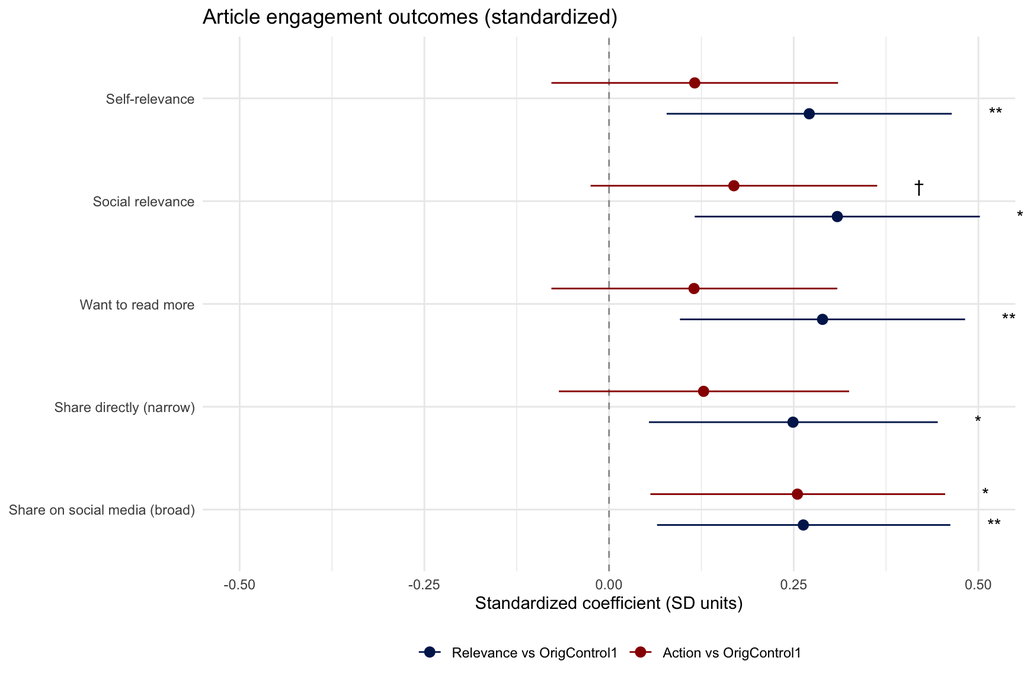

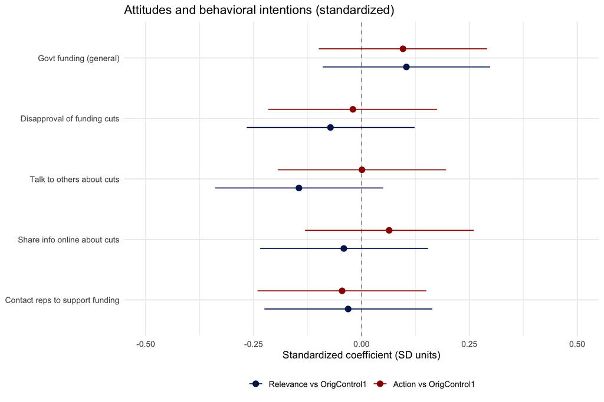

## Condition means

Condition means ± 1 SE in SD units. The zero line is the full-sample grand mean.

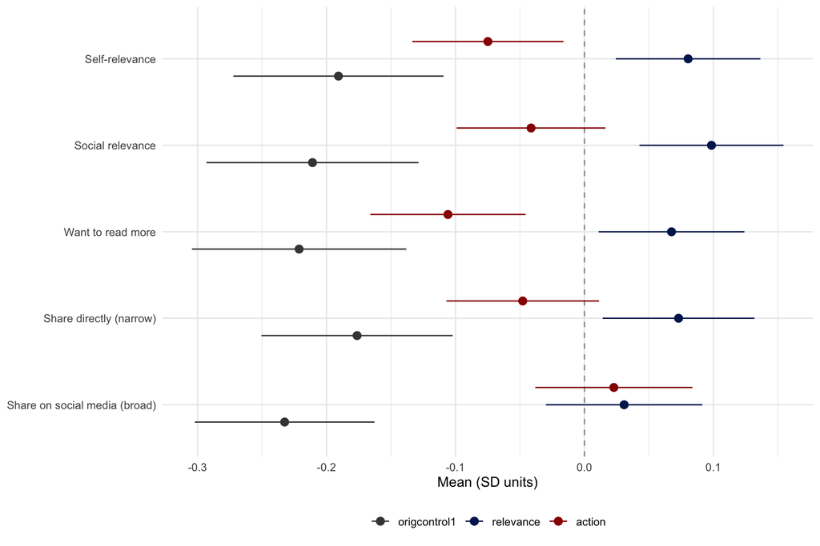

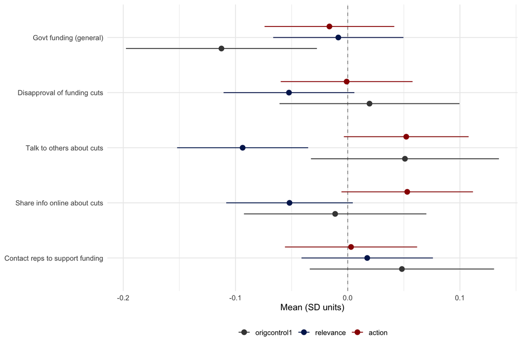

## Self-relevance → outcomes

Within-condition regression of each attitude/behavioral outcome on self-relevance (both z-scored). The coefficient equals the Pearson *r* between self-relevance and that outcome within each condition.

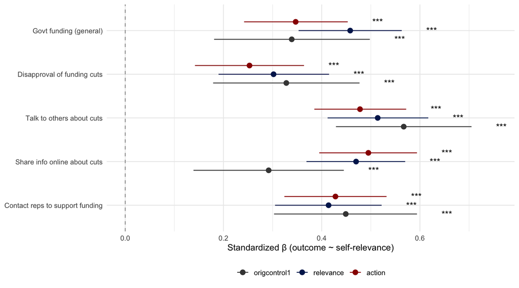

## Contrasts

| Outcome | Contrast | B | SE | t | p | sig | CI low | CI high |
| --- | --- | --- | --- | --- | --- | --- | --- | --- |
| Share directly (narrow) | relevance | 0.249 | 0.1 | 2.5 | 0.013 | * | 0.054 | 0.445 |
| Share directly (narrow) | action | 0.128 | 0.1 | 1.28 | 0.199 |  | -0.068 | 0.325 |
| Share on social media (broad) | relevance | 0.263 | 0.101 | 2.6 | 0.009 | ** | 0.065 | 0.462 |
| Share on social media (broad) | action | 0.255 | 0.102 | 2.51 | 0.012 | * | 0.056 | 0.455 |
| Want to read more | relevance | 0.289 | 0.098 | 2.94 | 0.003 | ** | 0.096 | 0.482 |
| Want to read more | action | 0.115 | 0.099 | 1.17 | 0.243 |  | -0.078 | 0.309 |
| Self-relevance | relevance | 0.271 | 0.099 | 2.75 | 0.006 | ** | 0.078 | 0.464 |
| Self-relevance | action | 0.116 | 0.099 | 1.17 | 0.242 |  | -0.078 | 0.31 |
| Social relevance | relevance | 0.309 | 0.098 | 3.14 | 0.002 | ** | 0.116 | 0.502 |
| Social relevance | action | 0.169 | 0.099 | 1.71 | 0.087 | † | -0.025 | 0.363 |

[output cut: 10 more lines]

## Effect sizes

| Outcome | Contrast | Cohen's d | CI low | CI high |
| --- | --- | --- | --- | --- |
| Share directly (narrow) | relevance | -0.254 | -0.45 | -0.057 |
| Share directly (narrow) | action | -0.131 | -0.328 | 0.066 |
| Share on social media (broad) | relevance | -0.268 | -0.467 | -0.068 |
| Share on social media (broad) | action | -0.262 | -0.462 | -0.061 |
| Want to read more | relevance | -0.288 | -0.483 | -0.093 |
| Want to read more | action | -0.111 | -0.306 | 0.084 |
| Self-relevance | relevance | -0.274 | -0.469 | -0.079 |
| Self-relevance | action | -0.115 | -0.31 | 0.08 |
| Social relevance | relevance | -0.312 | -0.507 | -0.117 |
| Social relevance | action | -0.169 | -0.364 | 0.026 |

[output cut: 10 more lines]

## Omnibus F-tests

| Outcome | R² | adj. R² | F | p | df | df resid. |
| --- | --- | --- | --- | --- | --- | --- |
| Share directly (narrow) | 0.008 | 0.005 | 2.525 | 0.039 | 4 | 1185 |
| Share on social media (broad) | 0.009 | 0.006 | 2.781 | 0.026 | 4 | 1169 |
| Want to read more | 0.017 | 0.014 | 5.146 | 0 | 4 | 1203 |
| Self-relevance | 0.013 | 0.009 | 3.888 | 0.004 | 4 | 1206 |
| Social relevance | 0.015 | 0.012 | 4.605 | 0.001 | 4 | 1206 |
| Govt funding (general) | 0.003 | 0 | 0.961 | 0.428 | 4 | 1206 |
| Disapproval of funding cuts | 0.001 | -0.002 | 0.321 | 0.864 | 4 | 1206 |
| Talk to others about cuts | 0.005 | 0.001 | 1.398 | 0.232 | 4 | 1206 |
| Share info online about cuts | 0.001 | -0.002 | 0.451 | 0.771 | 4 | 1206 |
| Contact reps to support funding | 0.001 | -0.002 | 0.27 | 0.897 | 4 | 1206 |

# 2. Variant-level analyses

Within the relevance and action conditions, participants saw one of three headline/lede variants. These analyses ask: (1) does each variant differ from control, and (2) do the three variants within each condition differ from each other?

## Coefficient plot

All coefficients in SD units (outcomes z-scored).

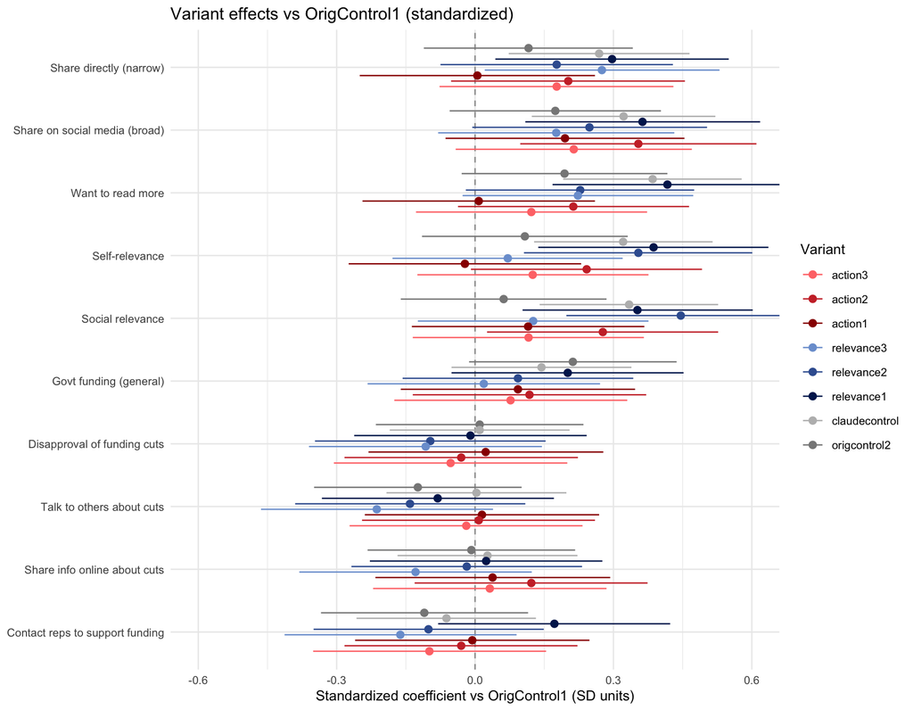

## Each variant vs Control

| Outcome | Variant | B | SE | t | p | sig | CI low | CI high |
| --- | --- | --- | --- | --- | --- | --- | --- | --- |
| Contact reps to support funding | action1 | -0.006 | 0.129 | -0.05 | 0.961 |  | -0.26 | 0.248 |
| Contact reps to support funding | action2 | -0.03 | 0.129 | -0.24 | 0.814 |  | -0.283 | 0.222 |
| Contact reps to support funding | action3 | -0.099 | 0.129 | -0.77 | 0.443 |  | -0.351 | 0.154 |
| Contact reps to support funding | claudecontrol | -0.062 | 0.099 | -0.63 | 0.53 |  | -0.257 | 0.132 |
| Contact reps to support funding | origcontrol2 | -0.11 | 0.115 | -0.96 | 0.338 |  | -0.334 | 0.115 |
| Contact reps to support funding | relevance1 | 0.172 | 0.128 | 1.34 | 0.181 |  | -0.08 | 0.423 |
| Contact reps to support funding | relevance2 | -0.101 | 0.127 | -0.79 | 0.429 |  | -0.35 | 0.149 |
| Contact reps to support funding | relevance3 | -0.162 | 0.128 | -1.26 | 0.208 |  | -0.413 | 0.09 |
| Disapproval of funding cuts | action1 | 0.023 | 0.13 | 0.18 | 0.859 |  | -0.231 | 0.278 |
| Disapproval of funding cuts | action2 | -0.03 | 0.129 | -0.23 | 0.815 |  | -0.283 | 0.223 |

[output cut: 70 more lines]

## Within-condition pairwise

| Outcome | Group | Contrast | Estimate | SE | t | p | sig |
| --- | --- | --- | --- | --- | --- | --- | --- |
| Contact reps to support funding | action | action1 - action2 | 0.024 | 0.142 | 0.168 | 0.985 |  |
| Contact reps to support funding | action | action1 - action3 | 0.092 | 0.142 | 0.649 | 0.793 |  |
| Contact reps to support funding | action | action2 - action3 | 0.068 | 0.141 | 0.483 | 0.879 |  |
| Contact reps to support funding | origcontrol | origcontrol1 - origcontrol2 | 0.11 | 0.115 | 0.958 | 0.338 |  |
| Contact reps to support funding | relevance | relevance1 - relevance2 | 0.272 | 0.14 | 1.948 | 0.126 |  |
| Contact reps to support funding | relevance | relevance1 - relevance3 | 0.333 | 0.141 | 2.367 | 0.047 | * |
| Contact reps to support funding | relevance | relevance2 - relevance3 | 0.061 | 0.14 | 0.436 | 0.9 |  |
| Disapproval of funding cuts | action | action1 - action2 | 0.053 | 0.142 | 0.373 | 0.926 |  |
| Disapproval of funding cuts | action | action1 - action3 | 0.076 | 0.142 | 0.535 | 0.854 |  |
| Disapproval of funding cuts | action | action2 - action3 | 0.023 | 0.142 | 0.163 | 0.985 |  |

[output cut: 60 more lines]

# 3. Moderation analyses

Five candidate moderators: **age**, **political ideology**, **climate belief — is warming happening** (`climate_warming`, 1–3), **climate belief — cause of warming** (`climate_cause`, 1–4), and **university affiliation** (binary). Continuous moderators are mean-centered. Each model is `outcome ~ condition * moderator`; interaction terms are extracted for relevance vs control and action vs control.

**180 interaction terms tested** (10 outcomes × 5 moderators × 2 contrasts). Expected significant by chance at *p* < .05: **9**. Observed *p* < .05: **14** — indistinguishable from chance. After FDR correction (Benjamini-Hochberg): **0** survive at *q* < .05, **0** at *q* < .10.

## All interactions

| Outcome | Moderator | Contrast | B | SE | t | p |  | p (FDR) |
| --- | --- | --- | --- | --- | --- | --- | --- | --- |
| Self-relevance | Political ideology | action | 0.142 | 0.053 | 2.701 | 0.007 | ** | 0.54 |
| Social relevance | Political ideology | action | 0.135 | 0.054 | 2.504 | 0.012 | * | 0.54 |
| Disapproval of funding cuts | Climate belief (happening) | relevance | -0.621 | 0.252 | -2.466 | 0.014 | * | 0.54 |
| Want to read more | Political ideology | NA | 0.136 | 0.056 | 2.432 | 0.015 | * | 0.54 |
| Disapproval of funding cuts | Climate belief (cause) | action | 0.357 | 0.146 | 2.435 | 0.015 | * | 0.54 |
| Want to read more | Political ideology | relevance | 0.126 | 0.054 | 2.31 | 0.021 | * | 0.56 |
| Disapproval of funding cuts | Climate belief (cause) | NA | 0.363 | 0.164 | 2.22 | 0.027 | * | 0.56 |
| Talk to others about cuts | Political ideology | relevance | 0.118 | 0.053 | 2.216 | 0.027 | * | 0.56 |
| Disapproval of funding cuts | Political ideology | action | 0.107 | 0.049 | 2.2 | 0.028 | * | 0.56 |
| Contact reps to support funding | Political ideology | action | 0.113 | 0.055 | 2.059 | 0.04 | * | 0.618 |

[output cut: 170 more lines]

## Interaction plot

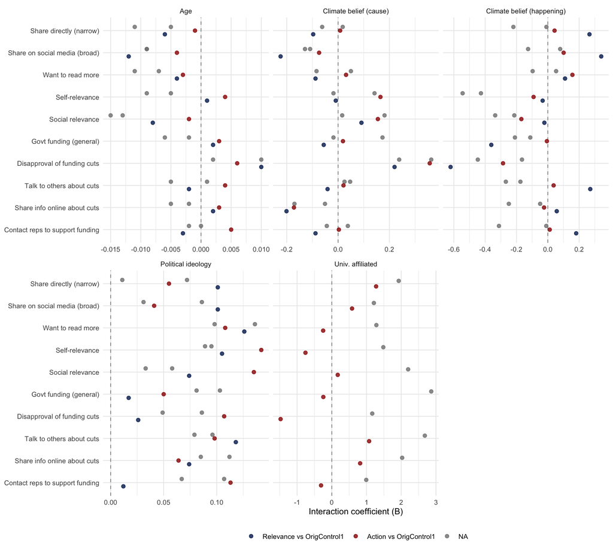

# 4. Interpretation

## What the old control was doing

claudecontrol is consistently and substantially higher than origcontrol1 across all five engagement outcomes: want to read more (B = 11.1, *p* < .001, *d* = 0.40), share on social media (B = 9.45, *p* = .002, *d* = 0.34), self-relevance (B = 0.55, *p* = .001, *d* = 0.33), social relevance (B = 0.54, *p* = .001, *d* = 0.34), share directly (B = 8.16, *p* = .007, *d* = 0.28). The old control article produced more engagement than the corrected control on its own — before any treatment comparison. Every effect estimated against it was therefore deflated, and apparent “backfire” in earlier analyses was at least partly an artifact of an elevated baseline.

## Condition-level effects

With the corrected reference, both the relevance and action frames show predominantly positive or null effects.

Neither condition affected government funding attitudes, behavioral intentions, or climate attitudes. These outcomes are likely too stable to shift from a single article exposure.

## Variant-level findings

**Within the relevance condition**, all three variants are positive, with relevance1 (“Most People Want to Do More About Climate Change. So Why Don’t They?”) producing the strongest effects: want to read more (B = 12.1, *p* = .001), self-relevance (B = 0.67, *p* = .002), share on social media (B = 10.7, *p* = .005), social relevance (B = 0.57, *p* = .006), and share directly (B = 9.01, *p* = .021). Relevance2 (“Climate Change Shapes the Way People Like You Think About the Future”) is reliably positive on social relevance (B = 0.72, *p* < .001) and self-relevance (B = 0.61, *p* = .005). Relevance3 shows a significant effect on share directly (B = 8.34, *p* = .034) and marginal effects elsewhere. The backfire on self-relevance previously observed for relevance3 does not replicate against the corrected control.

**Within the action condition**, action2 (“Not Sure What You Can Do?”) drives the aggregate condition effect: share on social media (B = 10.4, *p* = .007), social relevance (B = 0.45, *p* = .030), and marginal effects on self-relevance and want to read more. Action1 and action3 are null across all outcomes. This reverses the prior pattern in which action1 was the primary driver of backfire — those effects were artifacts of the inflated claudecontrol baseline.

## Theoretical synthesis

The corrected control changes the story substantially. Rather than a backfire from both conditions, we now see the relevance frame working as intended — improving engagement across sharing, perceived relevance, and interest in further reading. The action frame’s effects are more modest but not negative. The earlier backfire finding was driven by the old control article generating anomalously high engagement on its own, compressing or inverting treatment contrasts.

The variant pattern points to a consistent principle: frames that acknowledge the reader’s existing uncertainty or perspective (relevance1, relevance2, action2) perform better than those that feel prescriptive or that target a social influence motive (action1, action3, relevance3 in the old data). With the corrected baseline, however, even the weaker variants are null rather than harmful.

Government funding attitudes, behavioral intentions, and climate attitudes remain unaffected across all conditions and variants. These constructs may require repeated exposure or a more directly targeted manipulation.

## Moderation

180 interaction terms were tested (10 outcomes × 5 moderators × 2 contrasts). 14 reach nominal significance at *p* < .05 — near the expected number by chance (9). None survive FDR correction (Benjamini-Hochberg; all *q* > .10). No moderator reliably conditions the treatment effects.

# 5. Sensitivity analysis: excluding any auth flag

The primary analyses retain all participants who passed the 2+ flag exclusion threshold. Here we rerun the condition-level models excluding anyone with **any single authenticity flag** — reCAPTCHA < 0.5, Prolific bot = “mixed”, or failed attention check — regardless of how many flags they accumulated.

**N (full sample):** 1211 | **N (any-flag excluded):** 1153 (58 removed: 39 reCAPTCHA, 9 bot mixed, 10 attention fail)

## Comparison table

| outcome | contrast | B_full | p_full |  | B_sens | p_sens |  |
| --- | --- | --- | --- | --- | --- | --- | --- |
| Share on social media (broad) | action | 0.255 | 0.012 | * | 0.242 | 0.018 | * |
| Social relevance | action | 0.169 | 0.087 | † | 0.166 | 0.1 |  |
| Share directly (narrow) | action | 0.128 | 0.199 |  | 0.129 | 0.203 |  |
| Self-relevance | action | 0.116 | 0.242 |  | 0.107 | 0.287 |  |
| Want to read more | action | 0.115 | 0.243 |  | 0.114 | 0.256 |  |
| Govt funding (general) | action | 0.096 | 0.334 |  | 0.078 | 0.441 |  |
| Share info online about cuts | action | 0.064 | 0.519 |  | 0.083 | 0.413 |  |
| Contact reps to support funding | action | -0.045 | 0.649 |  | -0.052 | 0.614 |  |
| Disapproval of funding cuts | action | -0.02 | 0.838 |  | 0.024 | 0.812 |  |
| Talk to others about cuts | action | 0.001 | 0.991 |  | 0.027 | 0.792 |  |

[output cut: 10 more lines]

## Coefficient plot

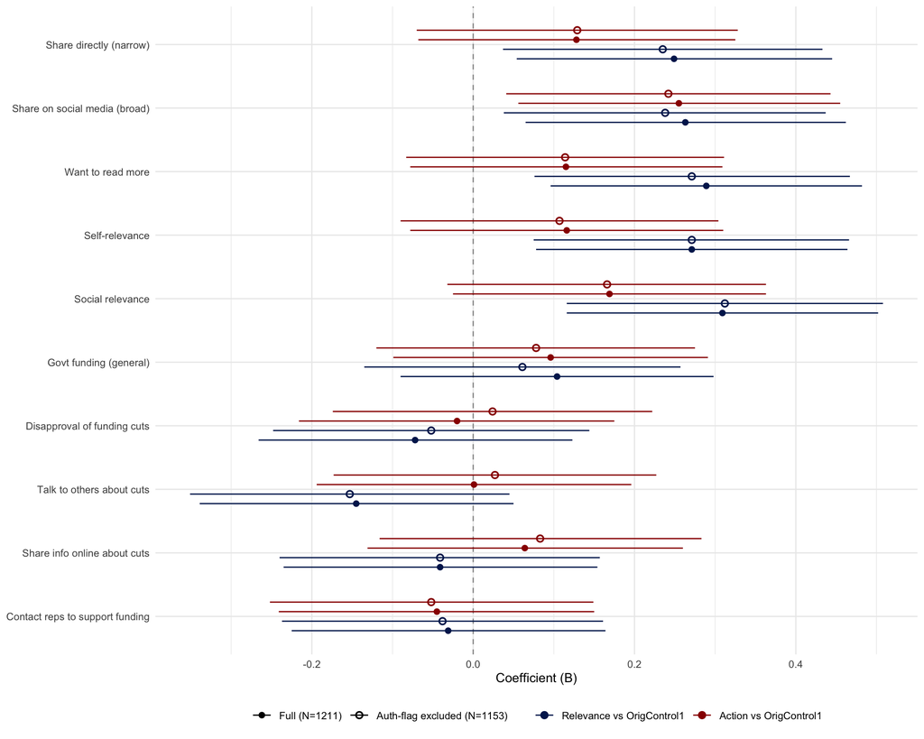

## Interpretation

Full sample N = 1211 | Auth-flag excluded N = 1153 (58 removed).

# 6. Subgroup analysis: political ideology

Note: this analysis was motivated by a pattern in the data (the categorical ideology × condition interaction that the continuous moderation in Section 3 missed). Interpret as exploratory.

## Coefficient plot

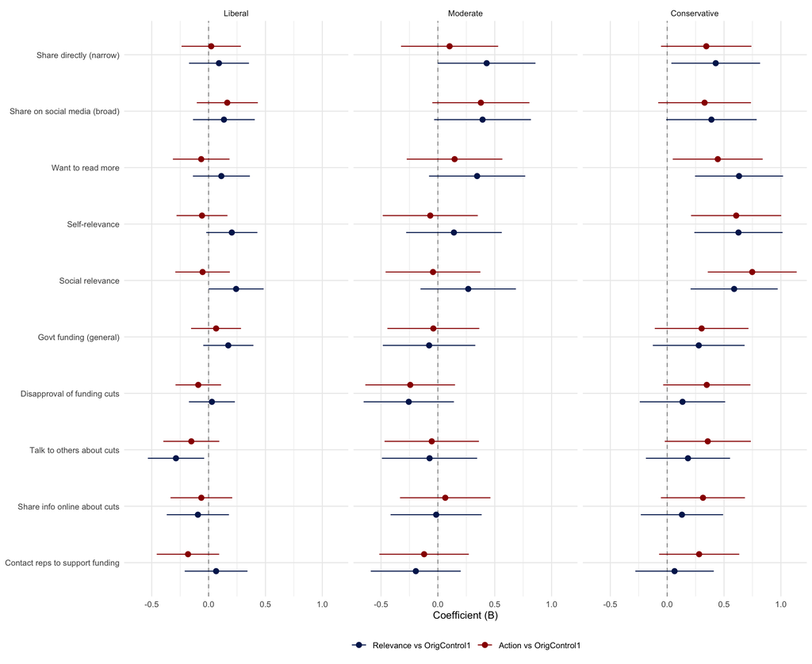

## Action condition

| Outcome | Group | B | SE | t | p |  | CI low | CI high |
| --- | --- | --- | --- | --- | --- | --- | --- | --- |
| Contact reps to support funding | Liberal | -0.181 | 0.14 | -1.3 | 0.195 |  | -0.456 | 0.093 |
| Contact reps to support funding | Moderate | -0.121 | 0.2 | -0.61 | 0.544 |  | -0.515 | 0.272 |
| Contact reps to support funding | Conservative | 0.281 | 0.179 | 1.57 | 0.118 |  | -0.071 | 0.634 |
| Disapproval of funding cuts | Liberal | -0.091 | 0.102 | -0.89 | 0.376 |  | -0.291 | 0.11 |
| Disapproval of funding cuts | Moderate | -0.243 | 0.2 | -1.22 | 0.225 |  | -0.638 | 0.151 |
| Disapproval of funding cuts | Conservative | 0.348 | 0.195 | 1.78 | 0.075 | † | -0.035 | 0.732 |
| Govt funding (general) | Liberal | 0.066 | 0.112 | 0.59 | 0.558 |  | -0.154 | 0.285 |
| Govt funding (general) | Moderate | -0.04 | 0.205 | -0.2 | 0.845 |  | -0.444 | 0.364 |
| Govt funding (general) | Conservative | 0.303 | 0.21 | 1.45 | 0.149 |  | -0.109 | 0.715 |
| Self-relevance | Liberal | -0.058 | 0.114 | -0.51 | 0.61 |  | -0.282 | 0.166 |

[output cut: 20 more lines]

## Relevance condition

| Outcome | Group | B | SE | t | p |  | CI low | CI high |
| --- | --- | --- | --- | --- | --- | --- | --- | --- |
| Contact reps to support funding | Liberal | 0.066 | 0.141 | 0.47 | 0.638 |  | -0.21 | 0.342 |
| Contact reps to support funding | Moderate | -0.194 | 0.201 | -0.97 | 0.334 |  | -0.59 | 0.201 |
| Contact reps to support funding | Conservative | 0.065 | 0.175 | 0.37 | 0.711 |  | -0.28 | 0.41 |
| Disapproval of funding cuts | Liberal | 0.029 | 0.103 | 0.29 | 0.775 |  | -0.173 | 0.231 |
| Disapproval of funding cuts | Moderate | -0.256 | 0.201 | -1.27 | 0.205 |  | -0.653 | 0.141 |
| Disapproval of funding cuts | Conservative | 0.135 | 0.191 | 0.71 | 0.481 |  | -0.241 | 0.51 |
| Govt funding (general) | Liberal | 0.173 | 0.112 | 1.54 | 0.123 |  | -0.047 | 0.394 |
| Govt funding (general) | Moderate | -0.077 | 0.206 | -0.37 | 0.708 |  | -0.484 | 0.329 |
| Govt funding (general) | Conservative | 0.278 | 0.205 | 1.35 | 0.177 |  | -0.126 | 0.681 |
| Self-relevance | Liberal | 0.204 | 0.115 | 1.78 | 0.076 | † | -0.021 | 0.429 |

[output cut: 20 more lines]

## Interpretation

For the action condition:

The pattern reverses what the earlier analysis found. With the corrected control, the framing effects are concentrated among **conservatives** rather than liberals.

For the action condition, conservatives show strong positive effects on social relevance (B = 1.21, *p* < .001), self-relevance (B = 1.05, *p* = .003), and want to read more (B = 12.9, *p* = .028). The relevance condition produces even broader positive effects among conservatives: want to read more (B = 18.3, *p* = .001), self-relevance (B = 1.08, *p* = .002), social relevance (B = 0.95, *p* = .003), climate attitude 3a (B = 0.75, *p* = .012), and share directly (B = 12.9, *p* = .032).

Liberals show minimal condition effects — relevance reduces talk intentions (B = −0.54, *p* = .023) and marginally increases social relevance. Moderates are largely null.

**Interpretation:** Under the old (inflated) control, liberals appeared to show reactance because their baseline engagement was already high — the claudecontrol article resonated with them regardless of frame, leaving little room for treatment effects. With the corrected control, conservatives — who were less engaged at baseline — show the larger gains from both framing conditions. The frames are moving the people with more room to move.

# 7. Believers-only analysis

Restricted to the **1043** participants who believe global warming is happening (`climate_warming` = “Yes”; excludes 168 who said No or Don’t know). Given the article is about climate change research, this subsample provides a cleaner test of the framing effects among the audience for whom the topic is personally relevant.

**Subsample N:** 1043 | Liberal: 577, Moderate: 217, Conservative: 248

## Full vs believers comparison

| outcome | contrast | B_full | p_full |  | B_bel | p_bel |  |
| --- | --- | --- | --- | --- | --- | --- | --- |
| Share on social media (broad) | action | 0.255 | 0.012 | * | 0.307 | 0.006 | ** |
| Social relevance | action | 0.169 | 0.087 | † | 0.213 | 0.032 | * |
| Share directly (narrow) | action | 0.128 | 0.199 |  | 0.171 | 0.111 |  |
| Self-relevance | action | 0.116 | 0.242 |  | 0.144 | 0.135 |  |
| Want to read more | action | 0.115 | 0.243 |  | 0.138 | 0.17 |  |
| Govt funding (general) | action | 0.096 | 0.334 |  | 0.124 | 0.198 |  |
| Share info online about cuts | action | 0.064 | 0.519 |  | 0.114 | 0.289 |  |
| Disapproval of funding cuts | action | -0.02 | 0.838 |  | -0.076 | 0.447 |  |
| Contact reps to support funding | action | -0.045 | 0.649 |  | -0.052 | 0.632 |  |
| Talk to others about cuts | action | 0.001 | 0.991 |  | 0.023 | 0.824 |  |

[output cut: 10 more lines]

## Coefficient plot

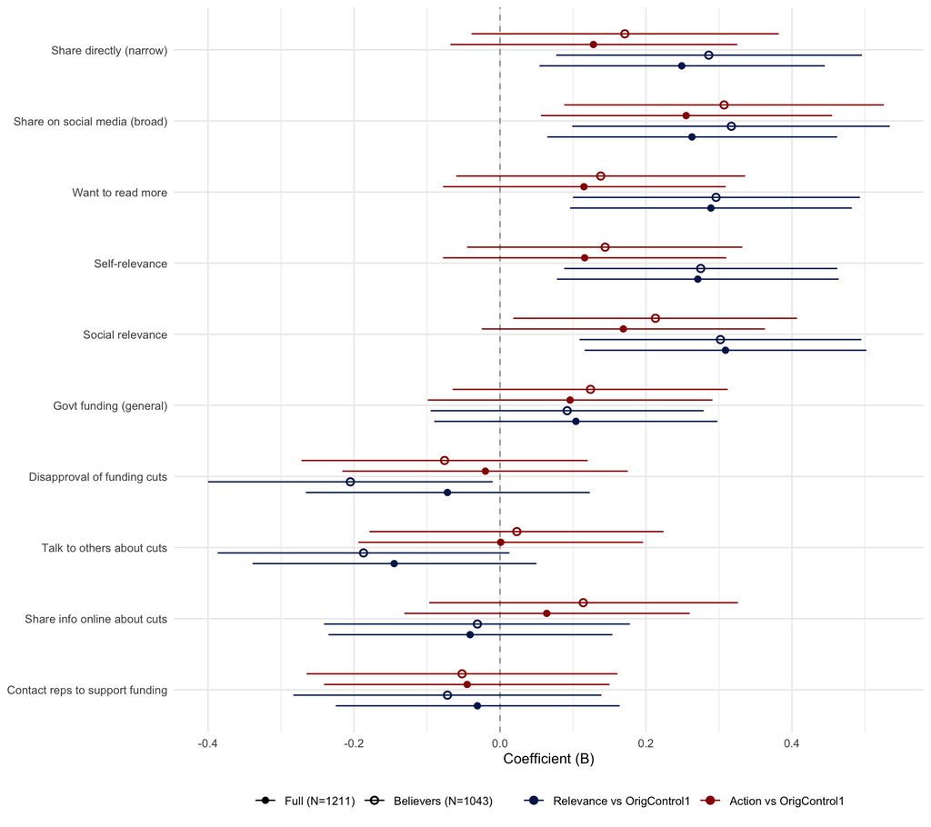

## By political group

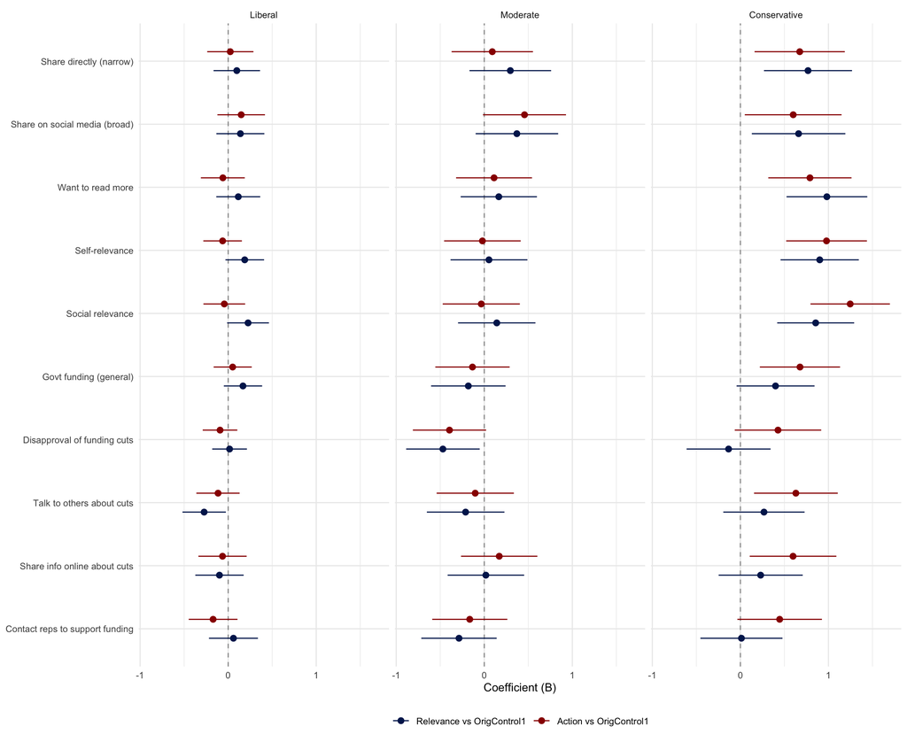

| Outcome | Group | Contrast | B | SE | t | p |  | CI low | CI high |
| --- | --- | --- | --- | --- | --- | --- | --- | --- | --- |
| Contact reps to support funding | Liberal | action | -0.171 | 0.141 | -1.21 | 0.226 |  | -0.448 | 0.106 |
| Contact reps to support funding | Moderate | action | -0.165 | 0.216 | -0.76 | 0.448 |  | -0.591 | 0.262 |
| Contact reps to support funding | Conservative | action | 0.446 | 0.244 | 1.83 | 0.069 | † | -0.034 | 0.926 |
| Disapproval of funding cuts | Liberal | action | -0.092 | 0.1 | -0.92 | 0.357 |  | -0.289 | 0.104 |
| Disapproval of funding cuts | Moderate | action | -0.395 | 0.211 | -1.87 | 0.062 | † | -0.811 | 0.021 |
| Disapproval of funding cuts | Conservative | action | 0.427 | 0.249 | 1.71 | 0.088 | † | -0.064 | 0.918 |
| Govt funding (general) | Liberal | action | 0.051 | 0.11 | 0.47 | 0.642 |  | -0.165 | 0.268 |
| Govt funding (general) | Moderate | action | -0.134 | 0.214 | -0.63 | 0.531 |  | -0.556 | 0.288 |
| Govt funding (general) | Conservative | action | 0.677 | 0.231 | 2.92 | 0.004 | ** | 0.221 | 1.132 |
| Self-relevance | Liberal | action | -0.063 | 0.111 | -0.56 | 0.575 |  | -0.282 | 0.156 |

[output cut: 50 more lines]

# 8. Save results

Results saved to /Users/nicolecooper/Documents/GitHub/UniversityNews/Step2/analysis/step2_results.rds.